# Maze Reaction-Time Preprocessing and Diagnostics

# 1 Overview

This report documents the import, integrity checks, iterative reaction-time (RT) cleaning, Box–Cox transformation, and distributional diagnostics used for the maze datasets. The workflow preserves all unique experimental rows, documents exact duplicate records separately, applies iterative relative RT removal before the exploratory, post-hoc 9,000-ms cutoff, and generates the tables and figures used for publication.

# 2 Data import and integrity checks

All CSV files are imported with raw header repair disabled. A versioned, deterministic normalization function then assigns unique analysis names while preserving every raw header in the schema manifest. Exact duplicate experimental records are identified before analysis; duplicate copies are excluded while their source-row counts remain documented.

Source-data checksum, row-count, raw-header, and import manifest.

| ManifestVersion | Dataset | RelativePath | Bytes | SHA256 | HeaderSHA256 | Columns | SourceRows | ExperimentalRows | NonexperimentalRows | ExactDuplicateExperimentalCopies | DuplicateRawHeaderNames | DuplicateRawHeaderExtraOccurrences | ExplicitSessionMetadataColumns | ImportDelimiter | ImportQuote | ImportEncoding | HeaderNormalization |
| --- | --- | --- | --- | --- | --- | --- | --- | --- | --- | --- | --- | --- | --- | --- | --- | --- | --- |
| 1 | fujita2024memoryEx1 | data/fujita2024memoryEx1.csv | 16,106,891 | 92abffe31d0c26f52762b9b880a478b788f47a7c93f0c23e660137d18b3243fb | b1b8f5e7e2293ec3ea9a88aa7c585d237a7312583c4e857dbb4c62a928d4eb77 | 11 | 226,560 | 226,560 | 0 | 0 | 0 | 0 | none | comma | double quote | platform default | explicit-v1 |
| 1 | fujita2024memoryEx2 | data/fujita2024memoryEx2.csv | 16,106,958 | 33ef37aeb5e035f1a062cbfbd2ab31d8f8f1c916570a4552395eecc362a7c132 | b1b8f5e7e2293ec3ea9a88aa7c585d237a7312583c4e857dbb4c62a928d4eb77 | 11 | 226,560 | 226,560 | 0 | 0 | 0 | 0 | none | comma | double quote | platform default | explicit-v1 |
| 1 | fujita2025lmaze | data/fujita2025lmaze.csv | 1,288,422 | 2c9bb024cf752ac7f64de83b6ba7edf865c45e629a4e8dae5cc6a7db6bd2b965 | 398bb2bd0ce6df43658d1e2120fc17d3e22beba28d309b237c71e3436befd12d | 11 | 19,080 | 19,080 | 0 | 0 | 0 | 0 | none | comma | double quote | platform default | explicit-v1 |
| 1 | fujita2026ex1 | data/fujita2026ex1.csv | 5,433,819 | d71b3d37a287a4f180e0f44cfc47d0846135477064a2a0097b191aadf9a76ab0 | c2b4beef35cb78e21d4764fb4202289318d5f7071ffec341a0cb1b3cfe183151 | 10 | 86,680 | 86,680 | 0 | 1,576 | 0 | 0 | none | comma | double quote | platform default | explicit-v1 |
| 1 | fujita2026ex2 | data/fujita2026ex2.csv | 1,626,938 | de5c524653ff1c86a39cb76958f0cc55bc220060c23363dab0ed801869486940 | 67c467229e14039dc891a3bcd583df41d5920b3835a3a66c181c1733aa9fd668 | 9 | 33,320 | 33,320 | 0 | 0 | 0 | 0 | none | comma | double quote | platform default | explicit-v1 |
| 1 | fujita2026ex3 | data/fujita2026ex3.csv | 2,728,128 | 9df9ba8e139e447a34b761be6d4fbdc1a5019ce258e093922c208d4088b8e826 | f26c6f5ad4680660c335829011263d4668709a7d1d37debe5d853557b0958676 | 10 | 43,606 | 43,606 | 0 | 0 | 0 | 0 | none | comma | double quote | platform default | explicit-v1 |
| 1 | fujitayoshida2024ex1 | data/fujitayoshida2024ex1.csv | 2,672,958 | 1c2abefe27a4ef545ab5e64847aef7dba38748eaa082c4b5566c0e50c8ed7376 | ad6e48ddc2ed80244d9d6cbe2afcd0411f540010fd7bc0c7278d3c78164ac23a | 12 | 40,752 | 40,752 | 0 | 0 | 0 | 0 | none | comma | double quote | platform default | explicit-v1 |
| 1 | fujitayoshida2024ex2 | data/fujitayoshida2024ex2.csv | 4,273,502 | 496ba8032faa4013d40abdd253393a6be990a0cd9473c709fcca687dc5f2f38c | ad6e48ddc2ed80244d9d6cbe2afcd0411f540010fd7bc0c7278d3c78164ac23a | 12 | 66,976 | 66,976 | 0 | 0 | 0 | 0 | none | comma | double quote | platform default | explicit-v1 |
| 1 | fujitayoshida2024ex3 | data/fujitayoshida2024ex3.csv | 2,095,797 | 2f6109e2e5ca3312b3f634deb77e1a3f86a5a79082f9bf4aca26d6271dac611d | ad6e48ddc2ed80244d9d6cbe2afcd0411f540010fd7bc0c7278d3c78164ac23a | 12 | 32,832 | 32,832 | 0 | 0 | 0 | 0 | none | comma | double quote | platform default | explicit-v1 |
| 1 | fujitayoshida2024ex4 | data/fujitayoshida2024ex4.csv | 1,831,287 | 3dfc6cbc71885d16527258ba1aeed00735e3e8835666877a3f0b2bd2b3bc7fb4 | 2bbb17897cc3beaffb6cff3d4cc8ab94cf73e0c6d8cbaaf56ddc4b86ad99f723 | 10 | 31,920 | 31,920 | 0 | 0 | 0 | 0 | none | comma | double quote | platform default | explicit-v1 |
| 1 | hao2025exp1b | data/hao2025exp1b.csv | 3,209,927 | 61611a5c850886ec0092c0cb8725e5647f91637a67b00af4a0dcb92b02658335 | f11fdfe4fc53adcdb790e54ff29596caf6b44113e259b3124dc121ba948267be | 11 | 74,000 | 31,500 | 42,500 | 0 | 0 | 0 | none | comma | double quote | platform default | explicit-v1 |
| 1 | hao2025exp2b | data/hao2025exp2b.csv | 6,384,924 | b08be6a54b97782ca3bd485c22387ce36f2a1919cb6e2ab64d7f5d2de168d4d2 | f11fdfe4fc53adcdb790e54ff29596caf6b44113e259b3124dc121ba948267be | 11 | 144,525 | 59,245 | 85,280 | 0 | 0 | 0 | none | comma | double quote | platform default | explicit-v1 |
| 1 | hoeks2023exp1 | data/hoeks2023exp1.csv | 41,246,124 | 9dbab966a9080a92a1d853afdcc8a6aa9d6cad0555a041b3b68ec4d72ed17baa | d49e78c5dc526c8784942c3aa024230511b23fd603362f97eb348316363afd0f | 14 | 478,476 | 47,250 | 431,226 | 0 | 1 | 7 | none | comma | double quote | platform default | explicit-v1 |
| 1 | hoeks2023exp2 | data/hoeks2023exp2.csv | 39,769,066 | c859bd9a19dbb56fe4d84b2c367894e9bc56f08d43d09b8fb7b8bad0b340e5db | d49e78c5dc526c8784942c3aa024230511b23fd603362f97eb348316363afd0f | 14 | 456,079 | 52,548 | 403,531 | 0 | 1 | 7 | none | comma | double quote | platform default | explicit-v1 |
| 1 | hoeks2023exp3 | data/hoeks2023exp3.csv | 35,921,980 | d84cc60a304c9c4b39cec4e045dfa93c1e60c028758cdf3853eaba99130c950f | d49e78c5dc526c8784942c3aa024230511b23fd603362f97eb348316363afd0f | 14 | 416,125 | 47,329 | 368,796 | 0 | 1 | 7 | none | comma | double quote | platform default | explicit-v1 |
| 1 | hoeks2023exp4 | data/hoeks2023exp4.csv | 11,786,757 | 43f189ba683b1ccc3f18f13816e06a0b6a7edefc5af09d6b5e57a256459d9ad4 | de6c3b58da5a31b9fbf42feffee55b6dc7c849604f73b6552177be5df9182a35 | 10 | 116,494 | 87,238 | 29,256 | 0 | 0 | 0 | none | comma | double quote | platform default | explicit-v1 |
| 1 | orth2025 | data/orth2025.csv | 5,244,251 | 43aa938ac747689a17f2a48569924ae2517fd023f4943e54069e313d22df1571 | 9b06f0d145ce23d0937c81e050ec4debbdc352133a7fe1fb0e8e889d4f275343 | 11 | 36,720 | 36,720 | 0 | 0 | 0 | 0 | none | comma | double quote | platform default | explicit-v1 |
| 1 | orth2026amaze | data/orth2026amaze.csv | 10,245,789 | 18015b8982e2ea156029aa56cbeaaa41f047cfbe925b34f1ca6f9c7a4b3c1015 | c5162cfe8c09832e6dd7a12d7ff9895027195b5a612632c0e4d4f2da6c80c8a1 | 15 | 98,094 | 19,968 | 78,126 | 0 | 2 | 8 | none | comma | double quote | platform default | explicit-v1 |
| 1 | orth2026lmaze | data/orth2026lmaze.csv | 9,099,106 | 6ccda5cd8d82ff15360f16eaf374e19639a3c67f36fbf998e97adecae47be5e4 | 766695ff7440b5acc8ef36fbe1ccce1d294637d9e80c9f69838fcee1a525ed77 | 15 | 47,159 | 19,200 | 27,959 | 0 | 1 | 8 | none | comma | double quote | platform default | explicit-v1 |

Explicit normalization of duplicate raw CSV headers. Blank raw names are shown as .

|  | ManifestVersion | Dataset | ColumnPosition | RawHeader | NormalizedHeader | RawHeaderOccurrences | Role |
| --- | --- | --- | --- | --- | --- | --- | --- |
| 3 | 1 | hoeks2023exp1 | 3 |  | unnamed__01 | 8 | source-specific |
| 5 | 1 | hoeks2023exp1 | 5 |  | unnamed__02 | 8 | source-specific |
| 7 | 1 | hoeks2023exp1 | 7 |  | unnamed__03 | 8 | source-specific |
| 9 | 1 | hoeks2023exp1 | 9 |  | unnamed__04 | 8 | source-specific |
| 10 | 1 | hoeks2023exp1 | 10 |  | unnamed__05 | 8 | source-specific |
| 11 | 1 | hoeks2023exp1 | 11 |  | unnamed__06 | 8 | source-specific |
| 12 | 1 | hoeks2023exp1 | 12 |  | unnamed__07 | 8 | source-specific |
| 14 | 1 | hoeks2023exp1 | 14 |  | unnamed__08 | 8 | source-specific |
| 31 | 1 | hoeks2023exp2 | 3 |  | unnamed__01 | 8 | source-specific |
| 51 | 1 | hoeks2023exp2 | 5 |  | unnamed__02 | 8 | source-specific |
| 71 | 1 | hoeks2023exp2 | 7 |  | unnamed__03 | 8 | source-specific |
| 91 | 1 | hoeks2023exp2 | 9 |  | unnamed__04 | 8 | source-specific |
| 101 | 1 | hoeks2023exp2 | 10 |  | unnamed__05 | 8 | source-specific |
| 111 | 1 | hoeks2023exp2 | 11 |  | unnamed__06 | 8 | source-specific |
| 121 | 1 | hoeks2023exp2 | 12 |  | unnamed__07 | 8 | source-specific |
| 141 | 1 | hoeks2023exp2 | 14 |  | unnamed__08 | 8 | source-specific |
| 32 | 1 | hoeks2023exp3 | 3 |  | unnamed__01 | 8 | source-specific |
| 52 | 1 | hoeks2023exp3 | 5 |  | unnamed__02 | 8 | source-specific |
| 72 | 1 | hoeks2023exp3 | 7 |  | unnamed__03 | 8 | source-specific |
| 92 | 1 | hoeks2023exp3 | 9 |  | unnamed__04 | 8 | source-specific |
| 102 | 1 | hoeks2023exp3 | 10 |  | unnamed__05 | 8 | source-specific |
| 112 | 1 | hoeks2023exp3 | 11 |  | unnamed__06 | 8 | source-specific |
| 122 | 1 | hoeks2023exp3 | 12 |  | unnamed__07 | 8 | source-specific |
| 142 | 1 | hoeks2023exp3 | 14 |  | unnamed__08 | 8 | source-specific |
| 18 | 1 | orth2026amaze | 1 | # | column__01 | 7 | source-specific |
| 33 | 1 | orth2026amaze | 3 | 0 | column_0__01 | 3 | source-specific |
| 53 | 1 | orth2026amaze | 5 | 0 | column_0__02 | 3 | source-specific |
| 73 | 1 | orth2026amaze | 7 | 0 | column_0__03 | 3 | source-specific |
| 93 | 1 | orth2026amaze | 9 | # | column__02 | 7 | source-specific |
| 103 | 1 | orth2026amaze | 10 | # | column__03 | 7 | source-specific |
| 113 | 1 | orth2026amaze | 11 | # | column__04 | 7 | source-specific |
| 123 | 1 | orth2026amaze | 12 | # | column__05 | 7 | source-specific |
| 143 | 1 | orth2026amaze | 14 | # | column__06 | 7 | source-specific |
| 15 | 1 | orth2026amaze | 15 | # | column__07 | 7 | source-specific |
| 34 | 1 | orth2026lmaze | 3 | 0 | column_0__01 | 9 | source-specific |
| 54 | 1 | orth2026lmaze | 5 | 0 | column_0__02 | 9 | source-specific |
| 74 | 1 | orth2026lmaze | 7 | 0 | column_0__03 | 9 | source-specific |
| 94 | 1 | orth2026lmaze | 9 | 0 | column_0__04 | 9 | source-specific |
| 104 | 1 | orth2026lmaze | 10 | 0 | column_0__05 | 9 | source-specific |
| 114 | 1 | orth2026lmaze | 11 | 0 | column_0__06 | 9 | source-specific |
| 124 | 1 | orth2026lmaze | 12 | 0 | column_0__07 | 9 | source-specific |
| 144 | 1 | orth2026lmaze | 14 | 0 | column_0__08 | 9 | source-specific |
| 151 | 1 | orth2026lmaze | 15 | 0 | column_0__09 | 9 | source-specific |

Source-row and exact-duplicate audit.

| Dataset | SourceRows | SourceExperimentalRows | ExactDuplicateExperimentalCopies | UniqueRowsRetained |
| --- | --- | --- | --- | --- |
| fujita2024memoryEx1 | 226,560 | 226,560 | 0 | 226,560 |
| fujita2024memoryEx2 | 226,560 | 226,560 | 0 | 226,560 |
| fujita2025lmaze | 19,080 | 19,080 | 0 | 19,080 |
| fujita2026ex1 | 86,680 | 86,680 | 1,576 | 85,104 |
| fujita2026ex2 | 33,320 | 33,320 | 0 | 33,320 |
| fujita2026ex3 | 43,606 | 43,606 | 0 | 43,606 |
| fujitayoshida2024ex1 | 40,752 | 40,752 | 0 | 40,752 |
| fujitayoshida2024ex2 | 66,976 | 66,976 | 0 | 66,976 |
| fujitayoshida2024ex3 | 32,832 | 32,832 | 0 | 32,832 |
| fujitayoshida2024ex4 | 31,920 | 31,920 | 0 | 31,920 |
| hao2025exp1b | 74,000 | 31,500 | 0 | 74,000 |
| hao2025exp2b | 144,525 | 59,245 | 0 | 144,525 |
| hoeks2023exp1 | 478,476 | 47,250 | 0 | 478,476 |
| hoeks2023exp2 | 456,079 | 52,548 | 0 | 456,079 |
| hoeks2023exp3 | 416,125 | 47,329 | 0 | 416,125 |
| hoeks2023exp4 | 116,494 | 87,238 | 0 | 116,494 |
| orth2025 | 36,720 | 36,720 | 0 | 36,720 |
| orth2026amaze | 98,094 | 19,968 | 0 | 98,094 |
| orth2026lmaze | 47,159 | 19,200 | 0 | 47,159 |

# 3 Iterative cleaning and session-level identifiers

Participant-session keys are constructed before cleaning so that complete repeated sessions stored under one source identifier are treated as separate analysis units. Iterative removal is evaluated independently within each condition and region. Source run/session fields are used when present. When they are absent, the audit records that metadata validation is unavailable; only exact multiples of a unique modal experimental-row count are reconstructed, and each inferred block must be contiguous and reproduce the same condition–item–region trajectory as its companion block.

Participant-label and analysis-session audit.

| Dataset | SourceParticipantLabels | AnalysisParticipants | ModalExperimentalRowsPerSession | AdditionalCompleteSessions | SessionConstruction | SourceSessionMetadata | MetadataValidation | BoundaryValidation |
| --- | --- | --- | --- | --- | --- | --- | --- | --- |
| fujita2024memoryEx1 | 640 | 640 | 354 | 0 | source_label_only | none | NOT_AVAILABLE | NOT_APPLICABLE |
| fujita2024memoryEx2 | 640 | 640 | 354 | 0 | source_label_only | none | NOT_AVAILABLE | NOT_APPLICABLE |
| fujita2025lmaze | 60 | 60 | 318 | 0 | source_label_only | none | NOT_AVAILABLE | NOT_APPLICABLE |
| fujita2026ex1 | 216 | 216 | 394 | 0 | source_label_only | none | NOT_AVAILABLE | NOT_APPLICABLE |
| fujita2026ex2 | 136 | 136 | 245 | 0 | source_label_only | none | NOT_AVAILABLE | NOT_APPLICABLE |
| fujita2026ex3 | 140 | 140 | 310 | 0 | source_label_only | none | NOT_AVAILABLE | NOT_APPLICABLE |
| fujitayoshida2024ex1 | 144 | 144 | 283 | 0 | source_label_only | none | NOT_AVAILABLE | NOT_APPLICABLE |
| fujitayoshida2024ex2 | 224 | 224 | 299 | 0 | source_label_only | none | NOT_AVAILABLE | NOT_APPLICABLE |
| fujitayoshida2024ex3 | 144 | 144 | 228 | 0 | source_label_only | none | NOT_AVAILABLE | NOT_APPLICABLE |
| fujitayoshida2024ex4 | 140 | 140 | 228 | 0 | source_label_only | none | NOT_AVAILABLE | NOT_APPLICABLE |
| hao2025exp1b | 100 | 100 | 315 | 0 | source_label_only | none | NOT_AVAILABLE | NOT_APPLICABLE |
| hao2025exp2b | 205 | 205 | 289 | 0 | source_label_only | none | NOT_AVAILABLE | NOT_APPLICABLE |
| hoeks2023exp1 | 55 | 55 | 858 | 0 | source_label_only | none | NOT_AVAILABLE | NOT_APPLICABLE |
| hoeks2023exp2 | 58 | 58 | 906 | 0 | source_label_only | none | NOT_AVAILABLE | NOT_APPLICABLE |
| hoeks2023exp3 | 53 | 53 | 893 | 0 | source_label_only | none | NOT_AVAILABLE | NOT_APPLICABLE |
| hoeks2023exp4 | 53 | 53 | 1,646 | 0 | source_label_only | none | NOT_AVAILABLE | NOT_APPLICABLE |
| orth2025 | 60 | 60 | 612 | 0 | source_label_only | none | NOT_AVAILABLE | NOT_APPLICABLE |
| orth2026amaze | 51 | 52 | 384 | 1 | row_count_reconstruction | none | NOT_AVAILABLE | PASS |
| orth2026lmaze | 50 | 50 | 384 | 0 | source_label_only | none | NOT_AVAILABLE | NOT_APPLICABLE |

De-identified source-row provenance for reconstructed session boundaries.

| Dataset | BoundaryAuditGroup | SessionToken | SourceRowFirst | SourceRowLast | ExperimentalRows | SourceRowsContiguous | ExperimentalSequenceContiguous | DesignSchemaCompatible |
| --- | --- | --- | --- | --- | --- | --- | --- | --- |
| orth2026amaze | B001 | S001 | 64,330 | 66,026 | 384 | FALSE | TRUE | TRUE |
| orth2026amaze | B001 | S002 | 66,214 | 67,912 | 384 | FALSE | TRUE | TRUE |

Apply the largest-first iterative procedure to the list of datasets. After each removal, comparison maxima are recomputed within the same dataset, analysis condition, and region. Iteration stops only when no remaining RT satisfies the removal rule.

Raw experimental-row audit before RT processing.

| Dataset | SourceExperimentalRows | ExactDuplicateExperimentalCopies | Participants | RawExperimentalRows | NumericRTs | NonNumericRTSlots | MinimumRowsPerParticipant | MedianRowsPerParticipant | MaximumRowsPerParticipant | BalancedRowsPerParticipant |
| --- | --- | --- | --- | --- | --- | --- | --- | --- | --- | --- |
| fujita2024memoryEx1 | 226,560 | 0 | 640 | 226,560 | 205,092 | 21,468 | 354 | 354 | 354 | TRUE |
| fujita2024memoryEx2 | 226,560 | 0 | 640 | 226,560 | 204,477 | 22,083 | 354 | 354 | 354 | TRUE |
| fujita2025lmaze | 19,080 | 0 | 60 | 19,080 | 17,094 | 1,986 | 318 | 318 | 318 | TRUE |
| fujita2026ex1 | 86,680 | 1,576 | 216 | 85,104 | 75,453 | 9,651 | 394 | 394 | 394 | TRUE |
| fujita2026ex2 | 33,320 | 0 | 136 | 33,320 | 30,685 | 2,635 | 245 | 245 | 245 | TRUE |
| fujita2026ex3 | 43,606 | 0 | 140 | 43,606 | 39,365 | 4,241 | 309 | 310 | 314 | FALSE |
| fujitayoshida2024ex1 | 40,752 | 0 | 144 | 40,752 | 36,274 | 4,478 | 283 | 283 | 283 | TRUE |
| fujitayoshida2024ex2 | 66,976 | 0 | 224 | 66,976 | 60,034 | 6,942 | 299 | 299 | 299 | TRUE |
| fujitayoshida2024ex3 | 32,832 | 0 | 144 | 32,832 | 30,249 | 2,583 | 228 | 228 | 228 | TRUE |
| fujitayoshida2024ex4 | 31,920 | 0 | 140 | 31,920 | 30,057 | 1,863 | 228 | 228 | 228 | TRUE |
| hao2025exp1b | 31,500 | 0 | 100 | 31,500 | 31,500 | 0 | 315 | 315 | 315 | TRUE |
| hao2025exp2b | 59,245 | 0 | 205 | 59,245 | 59,245 | 0 | 289 | 289 | 289 | TRUE |
| hoeks2023exp1 | 47,250 | 0 | 55 | 47,250 | 40,875 | 6,375 | 858 | 858 | 918 | FALSE |
| hoeks2023exp2 | 52,548 | 0 | 58 | 52,548 | 44,643 | 7,905 | 906 | 906 | 906 | TRUE |
| hoeks2023exp3 | 47,329 | 0 | 53 | 47,329 | 38,551 | 8,778 | 893 | 893 | 893 | TRUE |
| hoeks2023exp4 | 87,238 | 0 | 53 | 87,238 | 72,084 | 15,154 | 1,646 | 1,646 | 1,646 | TRUE |
| orth2025 | 36,720 | 0 | 60 | 36,720 | 31,033 | 5,687 | 612 | 612 | 612 | TRUE |
| orth2026amaze | 19,968 | 0 | 52 | 19,968 | 17,046 | 2,922 | 384 | 384 | 384 | TRUE |
| orth2026lmaze | 19,200 | 0 | 50 | 19,200 | 18,091 | 1,109 | 384 | 384 | 384 | TRUE |

# 4 Cleaned reaction-time distributions

These panels show experimental RTs after multiplier-1.5 iterative removal and the subsequent 9,000-ms cutoff.

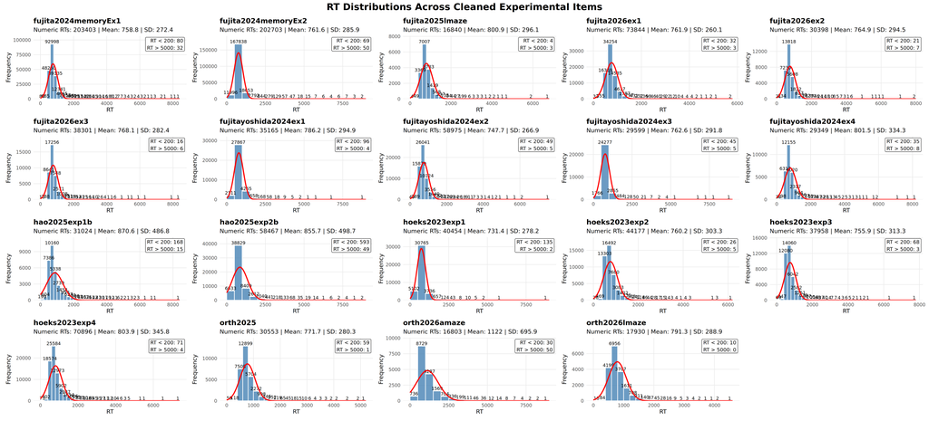

RT distributions after multiplier-1.5 iterative removal and the 9,000-ms cutoff.

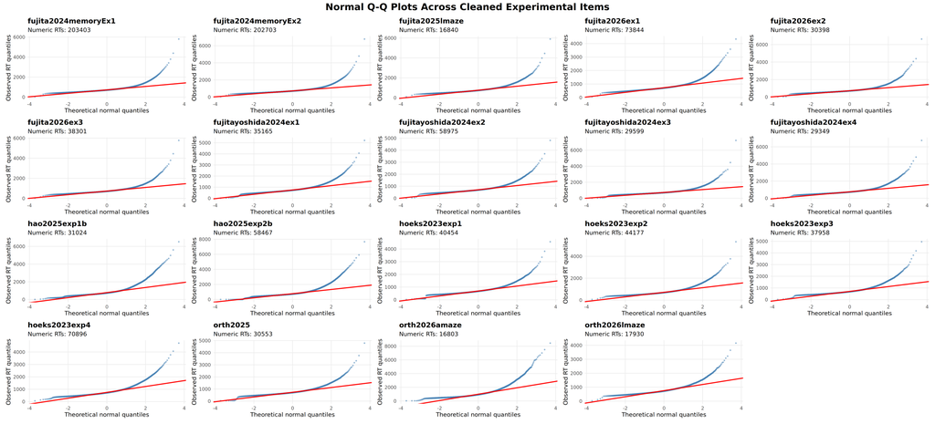

Normal Q–Q plots after multiplier-1.5 iterative removal and the 9,000-ms cutoff.

# 5 Xapd distribution-shape functions

The validated Xapd component and omnibus-test functions are loaded from the standalone `rt_process.R` implementation used by this report. Because the trial-level observations are crossed repeated measures, the resulting p-values are retained only as descriptive reference calculations; they are not used to accept or reject a model assumption.

# 6 Residual-versus-fitted plots and summary diagnostics

The same additive screening model is fitted separately to each dataset and stage:

The dataset-specific analysis-condition and region mappings are used. The raw stage includes experimental rows without the 9,000-ms cutoff. For multiplier 1.5, iterative removal is applied first and RTs above 9,000 ms are then removed, preserving the existing order of operations.

Xapd is calculated on each stage’s marginal finite RT distribution and is interpreted descriptively as a distribution-shape summary. Box–Cox lambda and the residual-versus-fitted plots are calculated from the additive screening model; finite nonpositive RTs are excluded from those two model-based diagnostics because Box–Cox requires a positive response. This screening model is not a reconstruction of each study’s final inferential model. Normality, constant variance, and influence must be evaluated from the conditional residuals and leave-one-cluster fits of the final model, including its planned fixed and random effects.

RT counts, iterative-removal totals, descriptive Xapd shape diagnostics, and Box–Cox estimates by dataset and stage.

| Dataset | Stage | Participants | RawExperimentalRows | NumericRTs | RT200to5000Removed | Xapd_Z_B2 | Xapd_Z_net_K2 | Xapd_Statistic | Xapd_PValue | BoxCoxLambda |
| --- | --- | --- | --- | --- | --- | --- | --- | --- | --- | --- |
| fujita2024memoryEx1 | Raw | 640 | 226,560 | 205,092 | 0 | 635.28 | 1,148.75 | 1,723,205.57 | 0 | -0.2 |
| fujita2024memoryEx2 | Raw | 640 | 226,560 | 204,477 | 0 | 669.04 | 1,494.60 | 2,681,442.77 | 0 | -0.2 |
| fujita2025lmaze | Raw | 60 | 19,080 | 17,094 | 0 | 165.86 | 245.48 | 87,773.31 | 0 | -0.7 |
| fujita2026ex1 | Raw | 216 | 85,104 | 75,453 | 0 | 401.88 | 825.23 | 842,504.23 | 0 | -0.3 |
| fujita2026ex2 | Raw | 136 | 33,320 | 30,685 | 0 | 249.56 | 444.78 | 260,108.22 | 0 | -0.1 |
| fujita2026ex3 | Raw | 140 | 43,606 | 39,365 | 0 | 292.02 | 549.93 | 387,697.55 | 0 | -0.3 |
| fujitayoshida2024ex1 | Raw | 144 | 40,752 | 36,274 | 0 | 266.01 | 455.51 | 278,251.32 | 0 | 0.0 |
| fujitayoshida2024ex2 | Raw | 224 | 66,976 | 60,034 | 0 | 332.78 | 554.59 | 418,309.06 | 0 | -0.1 |
| fujitayoshida2024ex3 | Raw | 144 | 32,832 | 30,249 | 0 | 256.10 | 470.18 | 286,652.98 | 0 | -0.1 |
| fujitayoshida2024ex4 | Raw | 140 | 31,920 | 30,057 | 0 | 249.72 | 423.47 | 241,685.86 | 0 | -0.1 |
| hao2025exp1b | Raw | 100 | 31,500 | 31,500 | 0 | 262.02 | 511.31 | 330,090.69 | 0 | -0.1 |
| hao2025exp2b | Raw | 205 | 59,245 | 59,245 | 0 | 361.43 | 778.07 | 736,028.60 | 0 | -0.1 |
| hoeks2023exp1 | Raw | 55 | 47,250 | 40,875 | 0 | 280.56 | 545.38 | 376,152.39 | 0 | 0.0 |
| hoeks2023exp2 | Raw | 58 | 52,548 | 44,643 | 0 | 216.45 | 218.99 | 94,807.61 | 0 | -0.4 |
| hoeks2023exp3 | Raw | 53 | 47,329 | 38,551 | 0 | 238.48 | 365.55 | 190,499.76 | 0 | -0.1 |
| hoeks2023exp4 | Raw | 53 | 87,238 | 72,084 | 0 | 301.16 | 497.21 | 337,917.39 | 0 | -0.3 |
| orth2025 | Raw | 60 | 36,720 | 31,033 | 0 | 257.73 | 516.20 | 332,887.14 | 0 | 0.0 |
| orth2026amaze | Raw | 52 | 19,968 | 17,046 | 0 | 174.24 | 252.60 | 94,168.80 | 0 | -0.2 |
| orth2026lmaze | Raw | 50 | 19,200 | 18,091 | 0 | 182.63 | 342.31 | 150,530.52 | 0 | -0.2 |
| fujita2024memoryEx1 | M1_5 | 640 | 226,560 | 203,403 | 1,535 | 377.85 | 274.96 | 218,375.99 | 0 | -0.2 |
| fujita2024memoryEx2 | M1_5 | 640 | 226,560 | 202,703 | 1,582 | 391.75 | 307.30 | 247,897.50 | 0 | -0.1 |
| fujita2025lmaze | M1_5 | 60 | 19,080 | 16,840 | 239 | 101.18 | 63.26 | 14,238.46 | 0 | -0.6 |
| fujita2026ex1 | M1_5 | 216 | 85,104 | 73,844 | 1,539 | 211.61 | 129.30 | 61,497.09 | 0 | -0.2 |
| fujita2026ex2 | M1_5 | 136 | 33,320 | 30,398 | 260 | 153.14 | 109.93 | 35,535.05 | 0 | -0.1 |
| fujita2026ex3 | M1_5 | 140 | 43,606 | 38,301 | 1,013 | 162.51 | 116.85 | 40,064.60 | 0 | -0.2 |
| fujitayoshida2024ex1 | M1_5 | 144 | 40,752 | 35,165 | 1,058 | 142.64 | 93.98 | 29,179.13 | 0 | 0.1 |
| fujitayoshida2024ex2 | M1_5 | 224 | 66,976 | 58,975 | 997 | 192.45 | 115.81 | 50,448.46 | 0 | 0.0 |
| fujitayoshida2024ex3 | M1_5 | 144 | 32,832 | 29,599 | 615 | 146.75 | 107.20 | 33,028.03 | 0 | 0.1 |
| fujitayoshida2024ex4 | M1_5 | 140 | 31,920 | 29,349 | 656 | 146.73 | 91.85 | 29,967.28 | 0 | 0.0 |
| hao2025exp1b | M1_5 | 100 | 31,500 | 31,024 | 381 | 150.94 | 55.87 | 25,905.77 | 0 | 0.0 |
| hao2025exp2b | M1_5 | 205 | 59,245 | 58,467 | 592 | 213.61 | 99.16 | 55,460.94 | 0 | 0.1 |
| hoeks2023exp1 | M1_5 | 55 | 47,250 | 40,454 | 398 | 146.83 | 88.57 | 29,403.36 | 0 | 0.1 |
| hoeks2023exp2 | M1_5 | 58 | 52,548 | 44,177 | 440 | 160.10 | 74.39 | 31,166.59 | 0 | -0.3 |
| hoeks2023exp3 | M1_5 | 53 | 47,329 | 37,958 | 564 | 153.71 | 74.32 | 29,151.82 | 0 | 0.0 |
| hoeks2023exp4 | M1_5 | 53 | 87,238 | 70,896 | 1,165 | 202.87 | 76.36 | 46,986.69 | 0 | -0.3 |
| orth2025 | M1_5 | 60 | 36,720 | 30,553 | 443 | 128.87 | 64.91 | 20,819.96 | 0 | 0.1 |
| orth2026amaze | M1_5 | 52 | 19,968 | 16,803 | 153 | 106.73 | 33.90 | 12,539.93 | 0 | -0.1 |
| orth2026lmaze | M1_5 | 50 | 19,200 | 17,930 | 158 | 92.33 | 37.94 | 9,965.09 | 0 | -0.1 |

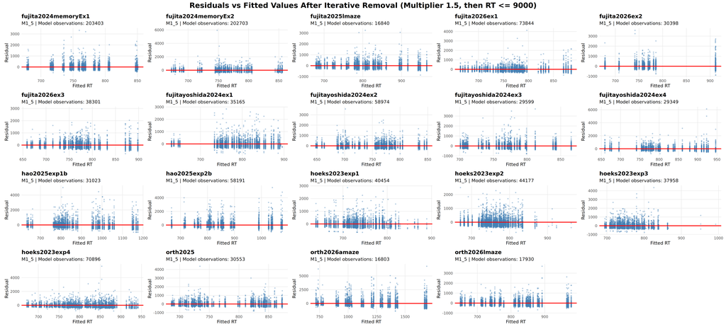

Residuals versus fitted values after multiplier-1.5 iterative removal and the 9,000-ms cutoff.

# 7 Box–Cox-transformed multiplier-1.5 screening diagnostics

Each multiplier-1.5 dataset is transformed using its own optimal Box–Cox lambda from `diagnostic_summary_table`. For lambda zero, the transformation is $\log(\mathrm{RT})$; otherwise it is $(\mathrm{RT}^{\lambda} - 1) / \lambda$. Box–Cox is defined only for positive RTs, so finite nonpositive values are represented as missing in `RT_BoxCox` and are excluded from these plots and models.

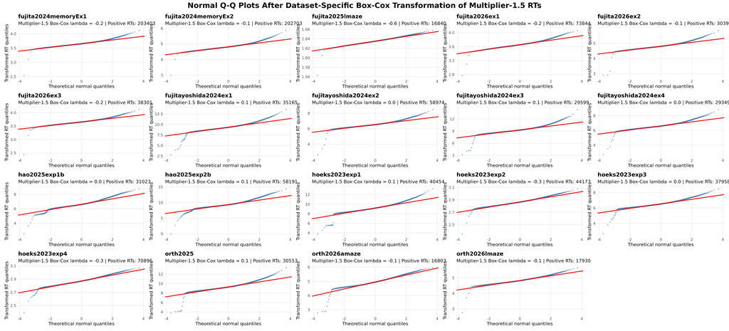

Normal Q–Q plots for multiplier-1.5 Box–Cox-transformed RTs.

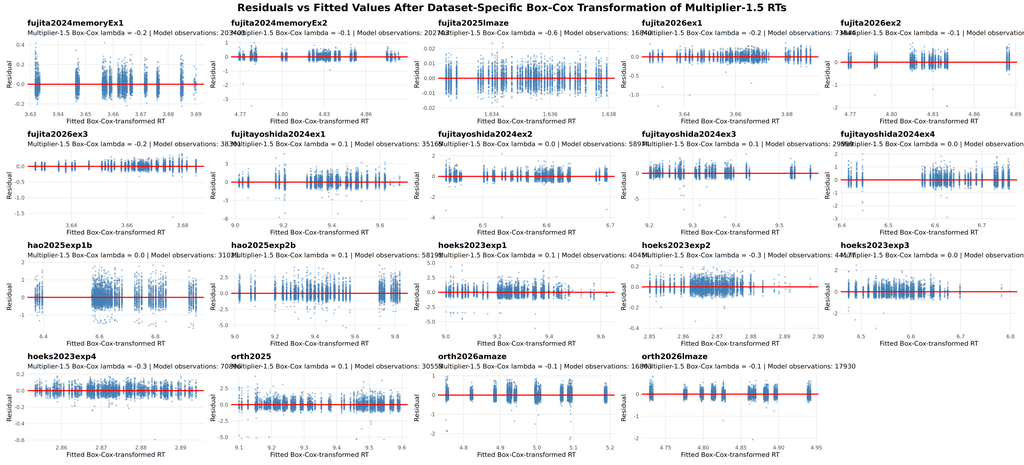

Residuals versus fitted values for multiplier-1.5 Box–Cox-transformed RTs.

# 8 Publication table and raw-versus-Box–Cox comparison figures

For direct comparison in the figures, Q–Q values, fitted values, and residuals are standardized separately within each dataset and stage. This preserves within-stage distributional shape and relative variance patterns, but it does not compare absolute residual variance across the two response scales. All residual panels use the same standardized display window, defined by the pooled 0.5th and 99.5th percentiles. The EPS output uses the exact dimensions of landscape A4 paper (11.69 by 8.27 inches). The residual panels remain screening plots from the additive condition-and-region model; inferential assumptions must be checked on the final study-specific model residuals.

## 8.1 Publication summary table

Adaptive reaction-time processing and distributional diagnostics.

| Dataset | Stage | m | N<sub>P</sub> | N<sub>raw</sub> | N<sub>RT</sub> | N<sub>iter</sub> | N<sub>>9k</sub> | %<sub>ref</sub> | Z<sub>B2</sub> | Z<sub>net.K2</sub> | X<sup>2</sup><sub>APD</sub> | p<sub>APD</sub> | λ |
| --- | --- | --- | --- | --- | --- | --- | --- | --- | --- | --- | --- | --- | --- |
| Fujita (2024), Memory Exp. 1 | Initial | NA | 640 | 226,560 | 205,092 | 0 | 0 | NA | 635.28 | 1,148.75 | 1,723,205.57 | < .001 | NA |
| Fujita (2024), Memory Exp. 1 | Clean | 1.5 | 640 | 226,560 | 203,403 | 1,683 | 6 | 0.72 | 377.85 | 274.96 | 218,375.99 | < .001 | -0.15 |
| Fujita (2024), Memory Exp. 1 | Box-Cox | 1.5 | 640 | 226,560 | 203,403 | NA | NA | NA | 94.61 | 175.27 | 39,668.80 | < .001 | -0.15 |
| Fujita (2024), Memory Exp. 2 | Initial | NA | 640 | 226,560 | 204,477 | 0 | 0 | NA | 669.04 | 1,494.60 | 2,681,442.77 | < .001 | NA |
| Fujita (2024), Memory Exp. 2 | Clean | 1.5 | 640 | 226,560 | 202,703 | 1,754 | 20 | 0.74 | 391.75 | 307.30 | 247,897.50 | < .001 | -0.15 |
| Fujita (2024), Memory Exp. 2 | Box-Cox | 1.5 | 640 | 226,560 | 202,703 | NA | NA | NA | 89.26 | 194.04 | 45,619.35 | < .001 | -0.15 |
| Fujita (2025), L-Maze | Initial | NA | 60 | 19,080 | 17,094 | 0 | 0 | NA | 165.86 | 245.48 | 87,773.31 | < .001 | NA |
| Fujita (2025), L-Maze | Clean | 1.5 | 60 | 19,080 | 16,840 | 254 | 0 | 1.37 | 101.18 | 63.26 | 14,238.46 | < .001 | -0.55 |
| Fujita (2025), L-Maze | Box-Cox | 1.5 | 60 | 19,080 | 16,840 | NA | NA | NA | 8.18 | 21.37 | 523.41 | < .001 | -0.55 |
| Fujita (2026), Exp. 1 | Initial | NA | 216 | 85,104 | 75,453 | 0 | 0 | NA | 401.88 | 825.23 | 842,504.23 | < .001 | NA |
| Fujita (2026), Exp. 1 | Clean | 1.5 | 216 | 85,104 | 73,844 | 1,609 | 0 | 2.02 | 211.61 | 129.30 | 61,497.09 | < .001 | -0.20 |
| Fujita (2026), Exp. 1 | Box-Cox | 1.5 | 216 | 85,104 | 73,844 | NA | NA | NA | 44.89 | 103.01 | 12,626.77 | < .001 | -0.20 |
| Fujita (2026), Exp. 2 | Initial | NA | 136 | 33,320 | 30,685 | 0 | 0 | NA | 249.56 | 444.78 | 260,108.22 | < .001 | NA |
| Fujita (2026), Exp. 2 | Clean | 1.5 | 136 | 33,320 | 30,398 | 287 | 0 | 0.81 | 153.14 | 109.93 | 35,535.05 | < .001 | -0.05 |
| Fujita (2026), Exp. 2 | Box-Cox | 1.5 | 136 | 33,320 | 30,398 | NA | NA | NA | 42.16 | 79.95 | 8,169.29 | < .001 | -0.05 |
| Fujita (2026), Exp. 3 | Initial | NA | 140 | 43,606 | 39,365 | 0 | 0 | NA | 292.02 | 549.93 | 387,697.55 | < .001 | NA |
| Fujita (2026), Exp. 3 | Clean | 1.5 | 140 | 43,606 | 38,301 | 1,061 | 3 | 2.55 | 162.51 | 116.85 | 40,064.60 | < .001 | -0.15 |
| Fujita (2026), Exp. 3 | Box-Cox | 1.5 | 140 | 43,606 | 38,301 | NA | NA | NA | 38.81 | 70.11 | 6,421.76 | < .001 | -0.15 |
| Fujita and Yoshida (2024), Exp. 1 | Initial | NA | 144 | 40,752 | 36,274 | 0 | 0 | NA | 266.01 | 455.51 | 278,251.32 | < .001 | NA |
| Fujita and Yoshida (2024), Exp. 1 | Clean | 1.5 | 144 | 40,752 | 35,165 | 1,106 | 3 | 2.88 | 142.64 | 93.98 | 29,179.13 | < .001 | 0.10 |
| Fujita and Yoshida (2024), Exp. 1 | Box-Cox | 1.5 | 144 | 40,752 | 35,165 | NA | NA | NA | 32.15 | 87.93 | 8,766.19 | < .001 | 0.10 |
| Fujita and Yoshida (2024), Exp. 2 | Initial | NA | 224 | 66,976 | 60,033 | 0 | 0 | NA | 332.79 | 554.58 | 418,310.84 | < .001 | NA |
| Fujita and Yoshida (2024), Exp. 2 | Clean | 1.5 | 224 | 66,976 | 58,974 | 1,053 | 6 | 1.62 | 192.50 | 115.75 | 50,455.27 | < .001 | 0.00 |
| Fujita and Yoshida (2024), Exp. 2 | Box-Cox | 1.5 | 224 | 66,976 | 58,974 | NA | NA | NA | 55.89 | 102.50 | 13,629.70 | < .001 | 0.00 |
| Fujita and Yoshida (2024), Exp. 3 | Initial | NA | 144 | 32,832 | 30,249 | 0 | 0 | NA | 256.10 | 470.18 | 286,652.98 | < .001 | NA |
| Fujita and Yoshida (2024), Exp. 3 | Clean | 1.5 | 144 | 32,832 | 29,599 | 648 | 2 | 2.01 | 146.75 | 107.20 | 33,028.03 | < .001 | 0.05 |
| Fujita and Yoshida (2024), Exp. 3 | Box-Cox | 1.5 | 144 | 32,832 | 29,599 | NA | NA | NA | 39.72 | 86.50 | 9,059.81 | < .001 | 0.05 |
| Fujita and Yoshida (2024), Exp. 4 | Initial | NA | 140 | 31,920 | 30,057 | 0 | 0 | NA | 249.72 | 423.47 | 241,685.86 | < .001 | NA |
| Fujita and Yoshida (2024), Exp. 4 | Clean | 1.5 | 140 | 31,920 | 29,349 | 705 | 3 | 2.12 | 146.73 | 91.85 | 29,967.28 | < .001 | 0.00 |
| Fujita and Yoshida (2024), Exp. 4 | Box-Cox | 1.5 | 140 | 31,920 | 29,349 | NA | NA | NA | 40.46 | 74.14 | 7,134.33 | < .001 | 0.00 |
| Hao (2025), Exp. 1b | Initial | NA | 100 | 31,500 | 31,499 | 0 | 0 | NA | 262.02 | 511.30 | 330,079.31 | < .001 | NA |
| Hao (2025), Exp. 1b | Clean | 1.5 | 100 | 31,500 | 31,023 | 473 | 3 | 1.10 | 150.96 | 55.85 | 25,909.18 | < .001 | -0.05 |
| Hao (2025), Exp. 1b | Box-Cox | 1.5 | 100 | 31,500 | 31,023 | NA | NA | NA | 28.11 | 61.56 | 4,579.94 | < .001 | -0.05 |
| Hao (2025), Exp. 2b | Initial | NA | 205 | 59,245 | 58,967 | 0 | 0 | NA | 360.58 | 776.01 | 732,204.92 | < .001 | NA |
| Hao (2025), Exp. 2b | Clean | 1.5 | 204 | 59,245 | 58,180 | 778 | 9 | 0.94 | 217.62 | 94.70 | 56,325.54 | < .001 | -0.05 |
| Hao (2025), Exp. 2b | Box-Cox | 1.5 | 204 | 59,245 | 58,180 | NA | NA | NA | 43.90 | 90.24 | 10,069.67 | < .001 | -0.05 |
| Hoeks (2023), Exp. 1 | Initial | NA | 55 | 47,250 | 40,875 | 0 | 0 | NA | 280.56 | 545.38 | 376,152.39 | < .001 | NA |
| Hoeks (2023), Exp. 1 | Clean | 1.5 | 55 | 47,250 | 40,454 | 420 | 1 | 0.93 | 146.83 | 88.57 | 29,403.36 | < .001 | 0.10 |
| Hoeks (2023), Exp. 1 | Box-Cox | 1.5 | 55 | 47,250 | 40,454 | NA | NA | NA | 34.69 | 79.16 | 7,469.64 | < .001 | 0.10 |
| Hoeks (2023), Exp. 2 | Initial | NA | 58 | 52,548 | 44,643 | 0 | 0 | NA | 216.45 | 218.99 | 94,807.61 | < .001 | NA |
| Hoeks (2023), Exp. 2 | Clean | 1.5 | 58 | 52,548 | 44,177 | 464 | 2 | 0.94 | 160.10 | 74.39 | 31,166.59 | < .001 | -0.30 |
| Hoeks (2023), Exp. 2 | Box-Cox | 1.5 | 58 | 52,548 | 44,177 | NA | NA | NA | 26.77 | 45.97 | 2,829.91 | < .001 | -0.30 |
| Hoeks (2023), Exp. 3 | Initial | NA | 53 | 47,329 | 38,551 | 0 | 0 | NA | 238.48 | 365.55 | 190,499.76 | < .001 | NA |
| Hoeks (2023), Exp. 3 | Clean | 1.5 | 53 | 47,329 | 37,958 | 593 | 0 | 1.41 | 153.71 | 74.32 | 29,151.82 | < .001 | -0.05 |
| Hoeks (2023), Exp. 3 | Box-Cox | 1.5 | 53 | 47,329 | 37,958 | NA | NA | NA | 36.33 | 72.21 | 6,534.53 | < .001 | -0.05 |
| Hoeks (2023), Exp. 4 | Initial | NA | 53 | 87,238 | 72,084 | 0 | 0 | NA | 301.16 | 497.21 | 337,917.39 | < .001 | NA |
| Hoeks (2023), Exp. 4 | Clean | 1.5 | 53 | 87,238 | 70,896 | 1,188 | 0 | 1.59 | 202.87 | 76.36 | 46,986.69 | < .001 | -0.25 |
| Hoeks (2023), Exp. 4 | Box-Cox | 1.5 | 53 | 87,238 | 70,896 | NA | NA | NA | 35.71 | 58.58 | 4,706.48 | < .001 | -0.25 |
| Orth (2025) | Initial | NA | 60 | 36,720 | 31,033 | 0 | 0 | NA | 257.73 | 516.20 | 332,887.14 | < .001 | NA |
| Orth (2025) | Clean | 1.5 | 60 | 36,720 | 30,553 | 480 | 0 | 1.37 | 128.87 | 64.91 | 20,819.96 | < .001 | 0.15 |
| Orth (2025) | Box-Cox | 1.5 | 60 | 36,720 | 30,553 | NA | NA | NA | 42.05 | 70.03 | 6,672.26 | < .001 | 0.15 |
| Orth (2026), A-Maze | Initial | NA | 52 | 19,968 | 17,046 | 0 | 0 | NA | 174.24 | 252.60 | 94,168.80 | < .001 | NA |
| Orth (2026), A-Maze | Clean | 1.5 | 52 | 19,968 | 16,803 | 236 | 7 | 0.77 | 106.73 | 33.90 | 12,539.93 | < .001 | -0.10 |
| Orth (2026), A-Maze | Box-Cox | 1.5 | 52 | 19,968 | 16,803 | NA | NA | NA | 15.36 | 27.10 | 970.14 | < .001 | -0.10 |
| Orth (2026), L-Maze | Initial | NA | 50 | 19,200 | 18,091 | 0 | 0 | NA | 182.63 | 342.31 | 150,530.52 | < .001 | NA |
| Orth (2026), L-Maze | Clean | 1.5 | 50 | 19,200 | 17,930 | 161 | 0 | 0.83 | 92.33 | 37.94 | 9,965.09 | < .001 | -0.15 |
| Orth (2026), L-Maze | Box-Cox | 1.5 | 50 | 19,200 | 17,930 | NA | NA | NA | 19.93 | 31.18 | 1,369.50 | < .001 | -0.15 |

## 8.2 Fixed-multiplier sensitivity comparison

The following sensitivity analysis applies multipliers 1.5, 2, and 3 as fixed values to the same analysis-eligible observations. It does not replace the adaptive primary results above. Removal reasons are recorded at the moment of removal, so an earlier ratio-based removal can create a later no-comparator removal.

Pooled removal comparison for fixed multipliers 1.5, 2, and 3.

| Multiplier | Eligible | No comparator | Participant + item ratio | Participant-only ratio | All iterative | 9,000-ms cutoff | Total removed | % eligible removed | <2,000 ms | =2,000 ms | >2,000 ms |
| --- | --- | --- | --- | --- | --- | --- | --- | --- | --- | --- | --- |
| 1.5 | 1,081,568 | 10,047 | 4,877 | 29 | 14,953 | 65 | 15,018 | 1.389 | 10,813 | 2 | 4,203 |
| 2.0 | 1,081,568 | 9,990 | 2,043 | 21 | 12,054 | 97 | 12,151 | 1.123 | 9,948 | 0 | 2,203 |
| 3.0 | 1,081,568 | 9,958 | 873 | 18 | 10,849 | 146 | 10,995 | 1.017 | 9,872 | 0 | 1,123 |

Dataset-level removal comparison for fixed multipliers 1.5, 2, and 3.

| Dataset | Multiplier | Eligible | No comparator | Ratio based | 9,000-ms cutoff | Total removed | % eligible removed | <2,000 ms | =2,000 ms | >2,000 ms |
| --- | --- | --- | --- | --- | --- | --- | --- | --- | --- | --- |
| Fujita (2024), Memory Exp. 1 | 1.5 | 205,092 | 1,293 | 390 | 6 | 1,689 | 0.824 | 1,287 | 0 | 402 |
| Fujita (2024), Memory Exp. 1 | 2.0 | 205,092 | 1,291 | 191 | 11 | 1,493 | 0.728 | 1,279 | 0 | 214 |
| Fujita (2024), Memory Exp. 1 | 3.0 | 205,092 | 1,286 | 105 | 17 | 1,408 | 0.687 | 1,274 | 0 | 134 |
| Fujita (2024), Memory Exp. 2 | 1.5 | 204,477 | 1,323 | 431 | 20 | 1,774 | 0.868 | 1,319 | 0 | 455 |
| Fujita (2024), Memory Exp. 2 | 2.0 | 204,477 | 1,318 | 232 | 25 | 1,575 | 0.770 | 1,304 | 0 | 271 |
| Fujita (2024), Memory Exp. 2 | 3.0 | 204,477 | 1,315 | 115 | 34 | 1,464 | 0.716 | 1,301 | 0 | 163 |
| Fujita (2025), L-Maze | 1.5 | 17,094 | 148 | 106 | 0 | 254 | 1.486 | 171 | 0 | 83 |
| Fujita (2025), L-Maze | 2.0 | 17,094 | 148 | 48 | 0 | 196 | 1.147 | 147 | 0 | 49 |
| Fujita (2025), L-Maze | 3.0 | 17,094 | 148 | 18 | 0 | 166 | 0.971 | 147 | 0 | 19 |
| Fujita (2026), Exp. 1 | 1.5 | 75,453 | 1,322 | 287 | 0 | 1,609 | 2.132 | 1,360 | 0 | 249 |
| Fujita (2026), Exp. 1 | 2.0 | 75,453 | 1,322 | 133 | 0 | 1,455 | 1.928 | 1,315 | 0 | 140 |
| Fujita (2026), Exp. 1 | 3.0 | 75,453 | 1,321 | 68 | 1 | 1,390 | 1.842 | 1,314 | 0 | 76 |
| Fujita (2026), Exp. 2 | 1.5 | 30,685 | 202 | 85 | 0 | 287 | 0.935 | 203 | 0 | 84 |
| Fujita (2026), Exp. 2 | 2.0 | 30,685 | 202 | 41 | 2 | 245 | 0.798 | 201 | 0 | 44 |
| Fujita (2026), Exp. 2 | 3.0 | 30,685 | 202 | 19 | 3 | 224 | 0.730 | 201 | 0 | 23 |
| Fujita (2026), Exp. 3 | 1.5 | 39,365 | 847 | 214 | 3 | 1,064 | 2.703 | 883 | 0 | 181 |
| Fujita (2026), Exp. 3 | 2.0 | 39,365 | 843 | 90 | 5 | 938 | 2.383 | 840 | 0 | 98 |
| Fujita (2026), Exp. 3 | 3.0 | 39,365 | 839 | 48 | 7 | 894 | 2.271 | 836 | 0 | 58 |
| Fujita and Yoshida (2024), Exp. 1 | 1.5 | 36,274 | 910 | 196 | 3 | 1,109 | 3.057 | 936 | 0 | 173 |
| Fujita and Yoshida (2024), Exp. 1 | 2.0 | 36,274 | 909 | 91 | 3 | 1,003 | 2.765 | 904 | 0 | 99 |
| Fujita and Yoshida (2024), Exp. 1 | 3.0 | 36,274 | 908 | 48 | 3 | 959 | 2.644 | 903 | 0 | 56 |
| Fujita and Yoshida (2024), Exp. 2 | 1.5 | 60,033 | 827 | 226 | 6 | 1,059 | 1.764 | 856 | 0 | 203 |
| Fujita and Yoshida (2024), Exp. 2 | 2.0 | 60,033 | 822 | 105 | 6 | 933 | 1.554 | 809 | 0 | 124 |
| Fujita and Yoshida (2024), Exp. 2 | 3.0 | 60,033 | 821 | 43 | 9 | 873 | 1.454 | 807 | 0 | 66 |
| Fujita and Yoshida (2024), Exp. 3 | 1.5 | 30,249 | 484 | 164 | 2 | 650 | 2.149 | 512 | 0 | 138 |
| Fujita and Yoshida (2024), Exp. 3 | 2.0 | 30,249 | 484 | 64 | 3 | 551 | 1.822 | 485 | 0 | 66 |
| Fujita and Yoshida (2024), Exp. 3 | 3.0 | 30,249 | 483 | 30 | 3 | 516 | 1.706 | 483 | 0 | 33 |
| Fujita and Yoshida (2024), Exp. 4 | 1.5 | 30,057 | 503 | 202 | 3 | 708 | 2.356 | 523 | 0 | 185 |
| Fujita and Yoshida (2024), Exp. 4 | 2.0 | 30,057 | 503 | 90 | 5 | 598 | 1.990 | 499 | 0 | 99 |
| Fujita and Yoshida (2024), Exp. 4 | 3.0 | 30,057 | 503 | 42 | 7 | 552 | 1.837 | 499 | 0 | 53 |
| Hao (2025), Exp. 1b | 1.5 | 31,499 | 203 | 270 | 3 | 476 | 1.511 | 225 | 0 | 251 |
| Hao (2025), Exp. 1b | 2.0 | 31,499 | 200 | 123 | 3 | 326 | 1.035 | 200 | 0 | 126 |
| Hao (2025), Exp. 1b | 3.0 | 31,499 | 200 | 55 | 6 | 261 | 0.829 | 200 | 0 | 61 |
| Hao (2025), Exp. 2b | 1.5 | 58,967 | 422 | 356 | 9 | 787 | 1.335 | 425 | 0 | 362 |
| Hao (2025), Exp. 2b | 2.0 | 58,967 | 420 | 176 | 17 | 613 | 1.040 | 415 | 0 | 198 |
| Hao (2025), Exp. 2b | 3.0 | 58,967 | 419 | 81 | 30 | 530 | 0.899 | 414 | 0 | 116 |
| Hoeks (2023), Exp. 1 | 1.5 | 40,875 | 155 | 265 | 1 | 421 | 1.030 | 245 | 0 | 176 |
| Hoeks (2023), Exp. 1 | 2.0 | 40,875 | 151 | 120 | 1 | 272 | 0.665 | 168 | 0 | 104 |
| Hoeks (2023), Exp. 1 | 3.0 | 40,875 | 147 | 48 | 1 | 196 | 0.480 | 157 | 0 | 39 |
| Hoeks (2023), Exp. 2 | 1.5 | 44,643 | 157 | 307 | 2 | 466 | 1.044 | 236 | 0 | 230 |
| Hoeks (2023), Exp. 2 | 2.0 | 44,643 | 148 | 105 | 2 | 255 | 0.571 | 151 | 0 | 104 |
| Hoeks (2023), Exp. 2 | 3.0 | 44,643 | 144 | 32 | 2 | 178 | 0.399 | 142 | 0 | 36 |
| Hoeks (2023), Exp. 3 | 1.5 | 38,551 | 319 | 274 | 0 | 593 | 1.538 | 387 | 0 | 206 |
| Hoeks (2023), Exp. 3 | 2.0 | 38,551 | 313 | 104 | 1 | 418 | 1.084 | 311 | 0 | 107 |
| Hoeks (2023), Exp. 3 | 3.0 | 38,551 | 309 | 28 | 2 | 339 | 0.879 | 302 | 0 | 37 |
| Hoeks (2023), Exp. 4 | 1.5 | 72,084 | 793 | 395 | 0 | 1,188 | 1.648 | 874 | 1 | 313 |
| Hoeks (2023), Exp. 4 | 2.0 | 72,084 | 782 | 106 | 0 | 888 | 1.232 | 769 | 0 | 119 |
| Hoeks (2023), Exp. 4 | 3.0 | 72,084 | 780 | 18 | 0 | 798 | 1.107 | 763 | 0 | 35 |
| Orth (2025) | 1.5 | 31,033 | 136 | 344 | 0 | 480 | 1.547 | 264 | 0 | 216 |
| Orth (2025) | 2.0 | 31,033 | 132 | 124 | 1 | 257 | 0.828 | 140 | 0 | 117 |
| Orth (2025) | 3.0 | 31,033 | 131 | 50 | 1 | 182 | 0.586 | 127 | 0 | 55 |
| Orth (2026), A-Maze | 1.5 | 17,046 | 3 | 233 | 7 | 243 | 1.426 | 32 | 0 | 211 |
| Orth (2026), A-Maze | 2.0 | 17,046 | 2 | 82 | 12 | 96 | 0.563 | 3 | 0 | 93 |
| Orth (2026), A-Maze | 3.0 | 17,046 | 2 | 31 | 20 | 53 | 0.311 | 2 | 0 | 51 |
| Orth (2026), L-Maze | 1.5 | 18,091 | 0 | 161 | 0 | 161 | 0.890 | 75 | 1 | 85 |
| Orth (2026), L-Maze | 2.0 | 18,091 | 0 | 39 | 0 | 39 | 0.216 | 8 | 0 | 31 |
| Orth (2026), L-Maze | 3.0 | 18,091 | 0 | 12 | 0 | 12 | 0.066 | 0 | 0 | 12 |

## 8.3 Structural no-comparator sensitivity

A row without another item for the same participant, condition, and region has no participant-side relative-RT comparator. This is structural missingness, not evidence that its RT is extreme. The reusable function therefore retains such rows by default. For the historical benchmark, the exclusion policy was requested explicitly because the prespecified relative criterion was undefined; it does not classify these rows by RT magnitude. The complete adaptive workflow was also run under the default retention policy, including rows that lose their final comparator during iteration. Multiplier selection, the 9,000-ms cutoff, Box–Cox estimation, and all diagnostics were recomputed from the retained data.

The table reports preprocessing changes and changes in the clean-millisecond condition-and-region diagnostic model rather than asserting that structural removals are harmless. The maximum standardized shift uses the primary coefficient’s standard error; sign changes exclude the intercept. This diagnostic-model comparison is an effect-scale warning, not a substitute for rerunning the study’s final inferential model with both processed datasets. Across the 19 datasets, retaining structural rows added 10,059 final RTs, changed the selected Box–Cox lambda in 2 datasets, and changed at least one non-intercept diagnostic-model coefficient sign in 4 datasets. The maximum standardized coefficient shift was 4.062. These results rule out a blanket claim that the structural policy is neutral.

Adaptive sensitivity to retaining structurally non-comparable rows.

| Dataset | Primary structural removals | Retention-policy structural removals | Primary m | Retention m | Primary final RTs | Retention final RTs | RT difference | Primary lambda | Retention lambda | Lambda difference | Maximum coefficient shift (ms) | Maximum standardized shift | Coefficient sign changes |
| --- | --- | --- | --- | --- | --- | --- | --- | --- | --- | --- | --- | --- | --- |
| Fujita (2024), Memory Exp. 1 | 1,293 | 0 | 1.5 | 1.5 | 203,403 | 204,697 | 1,294 | -0.15 | -0.15 | 0.00 | 14.662 | 2.135 | 0 |
| Fujita (2024), Memory Exp. 2 | 1,323 | 0 | 1.5 | 1.5 | 202,703 | 204,026 | 1,323 | -0.15 | -0.15 | 0.00 | 12.757 | 1.767 | 0 |
| Fujita (2025), L-Maze | 148 | 0 | 1.5 | 1.5 | 16,840 | 16,988 | 148 | -0.55 | -0.55 | 0.00 | 38.666 | 1.495 | 0 |
| Fujita (2026), Exp. 1 | 1,322 | 0 | 1.5 | 1.5 | 73,844 | 75,166 | 1,322 | -0.20 | -0.20 | 0.00 | 30.357 | 2.322 | 0 |
| Fujita (2026), Exp. 2 | 202 | 0 | 1.5 | 1.5 | 30,398 | 30,600 | 202 | -0.05 | -0.05 | 0.00 | 5.735 | 0.409 | 1 |
| Fujita (2026), Exp. 3 | 847 | 0 | 1.5 | 1.5 | 38,301 | 39,148 | 847 | -0.15 | -0.20 | -0.05 | 7.017 | 0.342 | 0 |
| Fujita and Yoshida (2024), Exp. 1 | 910 | 0 | 1.5 | 1.5 | 35,165 | 36,076 | 911 | 0.10 | 0.10 | 0.00 | 97.831 | 4.062 | 0 |
| Fujita and Yoshida (2024), Exp. 2 | 827 | 0 | 1.5 | 1.5 | 58,974 | 59,803 | 829 | 0.00 | 0.00 | 0.00 | 2.205 | 0.290 | 0 |
| Fujita and Yoshida (2024), Exp. 3 | 484 | 0 | 1.5 | 1.5 | 29,599 | 30,083 | 484 | 0.05 | 0.05 | 0.00 | 1.876 | 0.200 | 1 |
| Fujita and Yoshida (2024), Exp. 4 | 503 | 0 | 1.5 | 1.5 | 29,349 | 29,852 | 503 | 0.00 | 0.00 | 0.00 | 3.721 | 0.349 | 0 |
| Hao (2025), Exp. 1b | 203 | 0 | 1.5 | 1.5 | 31,023 | 31,226 | 203 | -0.05 | -0.05 | 0.00 | 0.863 | 0.043 | 0 |
| Hao (2025), Exp. 2b | 422 | 0 | 1.5 | 1.5 | 58,180 | 58,600 | 420 | -0.05 | 0.05 | 0.10 | 12.973 | 0.774 | 0 |
| Hoeks (2023), Exp. 1 | 155 | 0 | 1.5 | 1.5 | 40,454 | 40,610 | 156 | 0.10 | 0.10 | 0.00 | 92.184 | 3.770 | 0 |
| Hoeks (2023), Exp. 2 | 157 | 0 | 1.5 | 1.5 | 44,177 | 44,337 | 160 | -0.30 | -0.30 | 0.00 | 56.518 | 2.108 | 0 |
| Hoeks (2023), Exp. 3 | 319 | 0 | 1.5 | 1.5 | 37,958 | 38,279 | 321 | -0.05 | -0.05 | 0.00 | 91.679 | 2.254 | 0 |
| Hoeks (2023), Exp. 4 | 793 | 0 | 1.5 | 1.5 | 70,896 | 71,690 | 794 | -0.25 | -0.25 | 0.00 | 74.649 | 2.627 | 1 |
| Orth (2025) | 136 | 0 | 1.5 | 1.5 | 30,553 | 30,692 | 139 | 0.15 | 0.15 | 0.00 | 1.839 | 0.215 | 2 |
| Orth (2026), A-Maze | 3 | 0 | 1.5 | 1.5 | 16,803 | 16,806 | 3 | -0.10 | -0.10 | 0.00 | 1.015 | 0.041 | 0 |
| Orth (2026), L-Maze | 0 | 0 | 1.5 | 1.5 | 17,930 | 17,930 | 0 | -0.15 | -0.15 | 0.00 | 0.000 | 0.000 | 0 |

## 8.4 Reconstructed-session boundary sensitivity

No source CSV contains an explicit run or session identifier. Consequently, the source-metadata validation status is `NOT_AVAILABLE`, not `PASS`. Only the dataset listed below required row-count reconstruction after exact duplicate copies were removed. Its two inferred blocks are contiguous in the experimental-row sequence and each has a condition–item–region multiset observed in ordinary complete sessions; absolute CSV row numbers contain gaps because administrative rows are interleaved.

As a direct sensitivity check, the complete adaptive workflow was rerun with the original source participant label left unsplit. This comparison makes any effect of the reconstructed boundary visible rather than assuming that the row-count rule is neutral. The same clean-millisecond diagnostic-model coefficient comparison is reported; the study’s final inferential model must still be rerun under both session policies. For the reconstructed Orth A-Maze source label, leaving the label unsplit changed the final RT count by 4, did not change lambda or a coefficient sign, and produced a maximum standardized coefficient shift of 0.105.

Sensitivity to leaving row-count-reconstructed participant sessions unsplit.

| Dataset | Reconstructed sessions | Unsplit labels | Reconstructed m | Unsplit m | Reconstructed removals | Unsplit removals | Reconstructed final RTs | Unsplit final RTs | Reconstructed lambda | Unsplit lambda | Lambda difference | Maximum coefficient shift (ms) | Maximum standardized shift | Coefficient sign changes |
| --- | --- | --- | --- | --- | --- | --- | --- | --- | --- | --- | --- | --- | --- | --- |
| Orth (2026), A-Maze | 52 | 51 | 1.5 | 1.5 | 236 | 232 | 16,803 | 16,807 | -0.1 | -0.1 | 0 | 2.044 | 0.105 | 0 |

## 8.5 Post–Box–Cox integrity and sensitivity appendix

PASS means that the diagnostic criterion was met. REVIEW identifies a finding that requires substantive explanation and sensitivity interpretation; it is not an automatic reason to exclude a dataset. FAIL means that an integrity criterion was not met and must be resolved before relying on the transformed analysis. NOT_ASSESSABLE indicates that the available design or data did not support that diagnostic. To protect privacy, the publication tables omit participant and session identifiers, influential-cluster identifiers, and detailed trajectory signatures.

These are substantive warnings about cluster influence in the additive condition-and-region screening model, not evidence that the planned theoretical contrast changed in a study’s final model. Each REVIEW dataset therefore requires the planned final inferential model to be refitted after omitting the influential participant or item, with the focal estimate, uncertainty, and conclusion compared explicitly. Until that analysis is supplied, the corresponding final-model robustness claim remains unresolved rather than passed.

Post–Box–Cox integrity and sensitivity statuses for all 19 datasets.

| Dataset | Overall | Finite values | Positive variance | Monotonicity | Inverse recovery | Model estimability | Duplicate trajectories | Upper boundary | Participant deletion | Item deletion |
| --- | --- | --- | --- | --- | --- | --- | --- | --- | --- | --- |
| Fujita (2024), Memory Exp. 1 | REVIEW | PASS | PASS | PASS | PASS | PASS | REVIEW | PASS | PASS | REVIEW |
| Fujita (2024), Memory Exp. 2 | REVIEW | PASS | PASS | PASS | PASS | PASS | PASS | PASS | PASS | REVIEW |
| Fujita (2025), L-Maze | REVIEW | PASS | PASS | PASS | PASS | PASS | PASS | PASS | REVIEW | REVIEW |
| Fujita (2026), Exp. 1 | REVIEW | PASS | PASS | PASS | PASS | PASS | PASS | PASS | PASS | REVIEW |
| Fujita (2026), Exp. 2 | REVIEW | PASS | PASS | PASS | PASS | PASS | PASS | PASS | REVIEW | REVIEW |
| Fujita (2026), Exp. 3 | REVIEW | PASS | PASS | PASS | PASS | PASS | PASS | PASS | PASS | REVIEW |
| Fujita and Yoshida (2024), Exp. 1 | REVIEW | PASS | PASS | PASS | PASS | PASS | PASS | PASS | PASS | REVIEW |
| Fujita and Yoshida (2024), Exp. 2 | REVIEW | PASS | PASS | PASS | PASS | PASS | PASS | PASS | PASS | REVIEW |
| Fujita and Yoshida (2024), Exp. 3 | REVIEW | PASS | PASS | PASS | PASS | PASS | PASS | PASS | PASS | REVIEW |
| Fujita and Yoshida (2024), Exp. 4 | REVIEW | PASS | PASS | PASS | PASS | PASS | PASS | PASS | PASS | REVIEW |
| Hao (2025), Exp. 1b | REVIEW | PASS | PASS | PASS | PASS | PASS | PASS | PASS | PASS | REVIEW |
| Hao (2025), Exp. 2b | REVIEW | PASS | PASS | PASS | PASS | PASS | PASS | PASS | PASS | REVIEW |
| Hoeks (2023), Exp. 1 | REVIEW | PASS | PASS | PASS | PASS | PASS | PASS | PASS | REVIEW | REVIEW |
| Hoeks (2023), Exp. 2 | REVIEW | PASS | PASS | PASS | PASS | PASS | PASS | PASS | REVIEW | REVIEW |
| Hoeks (2023), Exp. 3 | REVIEW | PASS | PASS | PASS | PASS | PASS | PASS | PASS | REVIEW | REVIEW |
| Hoeks (2023), Exp. 4 | REVIEW | PASS | PASS | PASS | PASS | PASS | PASS | PASS | REVIEW | REVIEW |
| Orth (2025) | REVIEW | PASS | PASS | PASS | PASS | PASS | PASS | PASS | PASS | REVIEW |
| Orth (2026), A-Maze | REVIEW | PASS | PASS | PASS | PASS | PASS | PASS | PASS | REVIEW | PASS |
| Orth (2026), L-Maze | PASS | PASS | PASS | PASS | PASS | PASS | PASS | PASS | PASS | PASS |

### 8.5.1 Findings requiring review or resolution

The table below lists only REVIEW and FAIL outcomes and reports aggregate results suitable for publication.

Post–Box–Cox findings requiring review or resolution; identifying details are omitted.

| Dataset | Diagnostic | Status | Aggregate result |
| --- | --- | --- | --- |
| Fujita (2024), Memory Exp. 1 | Exact duplicated session trajectories | REVIEW | 2 duplicate groups among 640 assessable sessions |
| Fujita (2024), Memory Exp. 1 | Item-deletion sensitivity | REVIEW | maximum shift 6.852 SE; Region7 changed from 0.072689 to 0.06442 |
| Fujita (2024), Memory Exp. 2 | Item-deletion sensitivity | REVIEW | maximum shift 6.388 SE; Region7 changed from 0.070773 to 0.062892 |
| Fujita (2025), L-Maze | Participant-deletion sensitivity | REVIEW | maximum shift 1.073 SE; Region6 changed from 0.0049532 to 0.0052499 |
| Fujita (2025), L-Maze | Item-deletion sensitivity | REVIEW | maximum shift 2.256 SE; Region13 changed from 0.0029387 to 0.0043973 |
| Fujita (2026), Exp. 1 | Item-deletion sensitivity | REVIEW | maximum shift 3.048 SE; Region4 changed from -0.020423 to -0.015962 |
| Fujita (2026), Exp. 2 | Participant-deletion sensitivity | REVIEW | maximum shift 1.399 SE; Conditionca2 changed from -0.0023375 to -0.0057775 |
| Fujita (2026), Exp. 2 | Item-deletion sensitivity | REVIEW | maximum shift 2.543 SE; Region4 changed from -0.064422 to -0.050723 |
| Fujita (2026), Exp. 3 | Item-deletion sensitivity | REVIEW | maximum shift 2.296 SE; Region5 changed from -0.0056103 to 0.00048926 (sign changed) |
| Fujita and Yoshida (2024), Exp. 1 | Item-deletion sensitivity | REVIEW | maximum shift 2.816 SE; Region11 changed from 0.25348 to 0.1978 |
| Fujita and Yoshida (2024), Exp. 2 | Item-deletion sensitivity | REVIEW | maximum shift 3.137 SE; Region10 changed from 0.13966 to 0.12114 |
| Fujita and Yoshida (2024), Exp. 3 | Item-deletion sensitivity | REVIEW | maximum shift 2.105 SE; Region9 changed from 0.087259 to 0.058054 |
| Fujita and Yoshida (2024), Exp. 4 | Item-deletion sensitivity | REVIEW | maximum shift 1.962 SE; Region9 changed from 0.2199 to 0.19936 |
| Hao (2025), Exp. 1b | Item-deletion sensitivity | REVIEW | maximum shift 2.109 SE; Region13 changed from 0.14672 to 0.11876 |
| Hao (2025), Exp. 2b | Item-deletion sensitivity | REVIEW | maximum shift 4.867 SE; Region12 changed from 0.11881 to 0.066517 |
| Hoeks (2023), Exp. 1 | Participant-deletion sensitivity | REVIEW | maximum shift 4.047 SE; Region4 changed from 0.057078 to -0.014529 (sign changed) |
| Hoeks (2023), Exp. 1 | Item-deletion sensitivity | REVIEW | maximum shift 1.046 SE; Region20 changed from 0.46078 to 0.51932 |
| Hoeks (2023), Exp. 2 | Participant-deletion sensitivity | REVIEW | maximum shift 1.319 SE; Region7 changed from 0.0053455 to 0.0069624 |
| Hoeks (2023), Exp. 2 | Item-deletion sensitivity | REVIEW | maximum shift 1.126 SE; Region21 changed from 0.025521 to 0.02107 |
| Hoeks (2023), Exp. 3 | Participant-deletion sensitivity | REVIEW | maximum shift 2.106 SE; Region6 changed from 0.095308 to 0.0802 |
| Hoeks (2023), Exp. 3 | Item-deletion sensitivity | REVIEW | maximum shift 1.618 SE; Region23 changed from 0.22109 to 0.16914 |
| Hoeks (2023), Exp. 4 | Participant-deletion sensitivity | REVIEW | maximum shift 2.6 SE; Region7 changed from 0.027687 to 0.024145 |
| Hoeks (2023), Exp. 4 | Item-deletion sensitivity | REVIEW | maximum shift 1.646 SE; Region19 changed from 0.020199 to 0.015923 |
| Orth (2025) | Item-deletion sensitivity | REVIEW | maximum shift 1.226 SE; Region8 changed from 0.428 to 0.39485 |
| Orth (2026), A-Maze | Participant-deletion sensitivity | REVIEW | maximum shift 1.027 SE; Region1 changed from 0.33748 to 0.32952 |

### 8.5.2 De-identified duplicate-trajectory provenance

For every exact duplicate trajectory finding, the audit below supplies a dataset-local group token, a dataset-local session token, observation count, and original source-row span. It contains no participant label, reconstructed session identifier, or trajectory signature. The source-row span permits an authorized data custodian to reconcile a finding with the checksum-pinned source file without publishing the identifier itself.

De-identified provenance for exact duplicated eligible session trajectories.

| Dataset | Duplicate group | Session token | Observations | First source row | Last source row | Source rows contiguous |
| --- | --- | --- | --- | --- | --- | --- |
| Fujita (2024), Memory Exp. 1 | duplicate_group_001 | duplicate_session_001 | 338 | 40,003 | 40,356 | FALSE |
| Fujita (2024), Memory Exp. 1 | duplicate_group_001 | duplicate_session_002 | 338 | 40,357 | 40,710 | FALSE |
| Fujita (2024), Memory Exp. 1 | duplicate_group_002 | duplicate_session_003 | 306 | 183,019 | 183,372 | FALSE |
| Fujita (2024), Memory Exp. 1 | duplicate_group_002 | duplicate_session_004 | 306 | 183,373 | 183,726 | FALSE |

## 8.6 Publication comparison figures

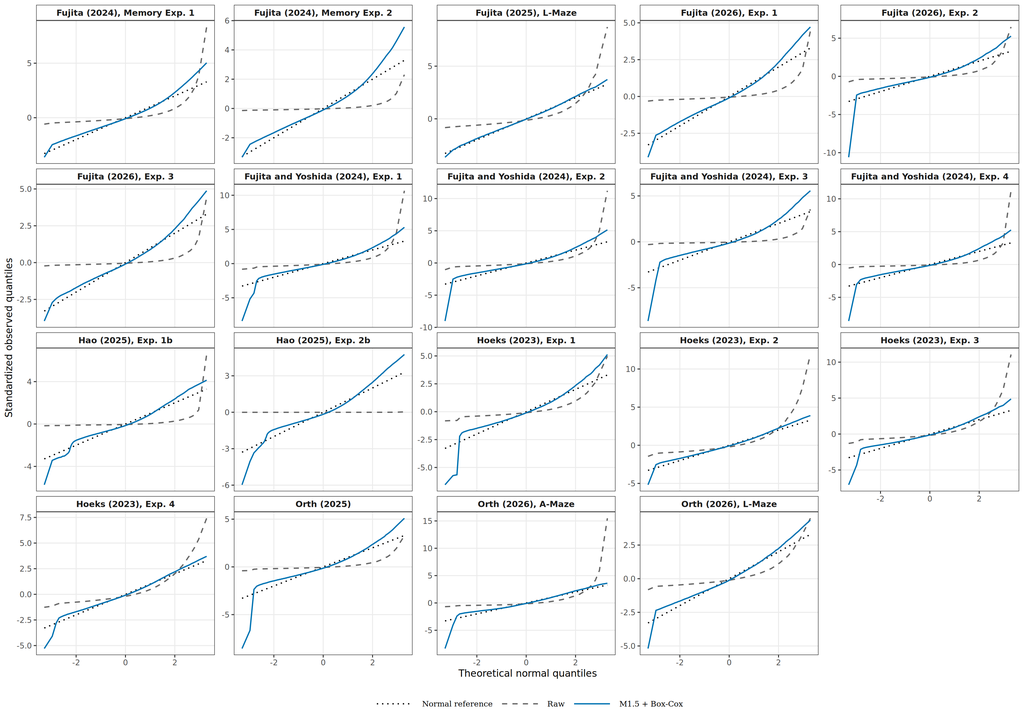

Normal Q–Q comparison of raw RTs and multiplier-1.5 Box–Cox-transformed RTs.

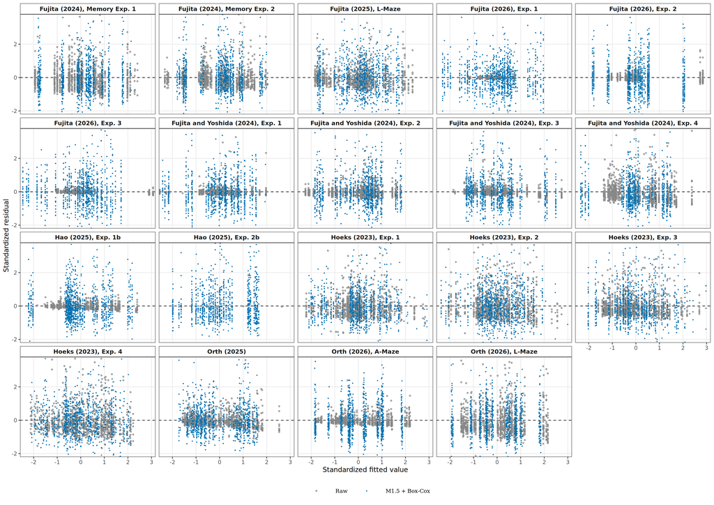

Residual-versus-fitted comparison of raw RTs and multiplier-1.5 Box–Cox-transformed RTs.